# Lifting weights

Stefan Troost

Saturday, December 20, 2014

### SYNOPSIS

In the sports science field of qualitative activity recognition, a possible way to determine the quality of an activity, in this case the lifting of dumbbells, is to use on-body sensing. Research has been carried out with a number of sensors attached to the human body. Actually 3 sensors were attached to the body: one in a belt around the waiste, one on the forearm and one on the arm. A fourth sensor was attached to the dumbbell itself, see the picture below.

[figure not shown]

### DATA

As a first step we just read the data as is, both the training and testing data.

```r
trainingData <- read.csv("D:/Stefan/Cursus/Specialization Data Science/8 Practical Machine Learning/Assignment/pml-training.csv")
testingData <- read.csv("D:/Stefan/Cursus/Specialization Data Science/8 Practical Machine Learning/Assignment/pml-testing.csv")

summary(trainingData)
```

```
##        X            user_name    raw_timestamp_part_1 raw_timestamp_part_2
##  Min.   :    1   adelmo  :3892   Min.   :1.32e+09     Min.   :   294
##  1st Qu.: 4906   carlitos:3112   1st Qu.:1.32e+09     1st Qu.:252912
##  Median : 9812   charles :3536   Median :1.32e+09     Median :496380
##  Mean   : 9812   eurico  :3070   Mean   :1.32e+09     Mean   :500656
##  3rd Qu.:14717   jeremy  :3402   3rd Qu.:1.32e+09     3rd Qu.:751891
##  Max.   :19622   pedro   :2610   Max.   :1.32e+09     Max.   :998801
##
##           cvtd_timestamp  new_window    num_window    roll_belt
##  28/11/2011 14:14: 1498   no :19216   Min.   :  1   Min.   :-28.9
##  05/12/2011 11:24: 1497   yes:  406   1st Qu.:222   1st Qu.:  1.1
##  30/11/2011 17:11: 1440               Median :424   Median :113.0
##  05/12/2011 11:25: 1425               Mean   :431   Mean   : 64.4
##  02/12/2011 14:57: 1380               3rd Qu.:644   3rd Qu.:123.0
##  02/12/2011 13:34: 1375               Max.   :864   Max.   :162.0
##  (Other)         :11007
##    pitch_belt        yaw_belt      total_accel_belt kurtosis_roll_belt
##  Min.   :-55.80   Min.   :-180.0   Min.   : 0.0              :19216
##  1st Qu.:  1.76   1st Qu.: -88.3   1st Qu.: 3.0     #DIV/0!  :   10
##  Median :  5.28   Median : -13.0   Median :17.0     -1.908453:    2
##  Mean   :  0.31   Mean   : -11.2   Mean   :11.3     -0.016850:    1
##  3rd Qu.: 14.90   3rd Qu.:  12.9   3rd Qu.:18.0     -0.021024:    1
##  Max.   : 60.30   Max.   : 179.0   Max.   :29.0     -0.025513:    1
##                                                     (Other)  :  391
##  kurtosis_picth_belt kurtosis_yaw_belt skewness_roll_belt
##           :19216            :19216              :19216
##  #DIV/0!  :   32     #DIV/0!:  406     #DIV/0!  :    9
##  47.000000:    4                       0.000000 :    4
##  -0.150950:    3                       0.422463 :    2
##  -0.684748:    3                       -0.003095:    1
##  -1.750749:    3                       -0.010002:    1
##  (Other)  :  361                       (Other)  :  389
##  skewness_roll_belt.1 skewness_yaw_belt max_roll_belt   max_picth_belt
##           :19216             :19216     Min.   :-94     Min.   : 3
##  #DIV/0!  :   32      #DIV/0!:  406     1st Qu.:-88     1st Qu.: 5
##  0.000000 :    4                        Median : -5     Median :18
##  -2.156553:    3                        Mean   : -7     Mean   :13
##  -3.072669:    3                        3rd Qu.: 18     3rd Qu.:19
##  -6.324555:    3                        Max.   :180     Max.   :30
##  (Other)  :  361                        NA's   :19216   NA's   :19216
```

[output cut: 289 more lines]

```
##  Min.   : -8.09   Min.   :-498.0   Min.   :-632    Min.   :-446.0
##  1st Qu.: -0.18   1st Qu.:-178.0   1st Qu.:  57    1st Qu.:-182.0
##  Median :  0.08   Median : -57.0   Median : 201    Median : -39.0
##  Mean   :  0.15   Mean   : -61.7   Mean   : 164    Mean   : -55.3
##  3rd Qu.:  0.49   3rd Qu.:  76.0   3rd Qu.: 312    3rd Qu.:  26.0
##  Max.   :231.00   Max.   : 477.0   Max.   : 923    Max.   : 291.0
##
##  magnet_forearm_x magnet_forearm_y magnet_forearm_z classe
##  Min.   :-1280    Min.   :-896     Min.   :-973     A:5580
##  1st Qu.: -616    1st Qu.:   2     1st Qu.: 191     B:3797
##  Median : -378    Median : 591     Median : 511     C:3422
##  Mean   : -313    Mean   : 380     Mean   : 394     D:3216
##  3rd Qu.:  -73    3rd Qu.: 737     3rd Qu.: 653     E:3607
##  Max.   :  672    Max.   :1480     Max.   :1090
##
```

In total, there are 160 variables, of which the last variable “classe” represents the class of execution (see synopsis), our variable to predict. If we take a look at the other 159, potentially predicting, variables, it can be easily noticed that quite a large number of them have very few valuable observation values. Many variables have a lot of NA or blank values. If we look at the testing data set, we can distinguish 100 variables that only have NA values.

### PRE-PROCESSING

we want to predict the classe of the lifting exercise with the use of the sensor data and will therefore leave out the first 7 non-sensor variables (“X”, “user _ name”, “raw _ timestamp _ part _ 1”, “raw _ timestamp _ part _ 2”, “cvtd _ timestamp”, “new _ window” and “num _ window”). Furthermore we want to leave out the variables with only NA values as they do not have any distinguishable values to use for prediction.

```r
trainingData <- trainingData[,-c(1,2,3,4,5,6,7)]
testingData <- testingData[,-c(1,2,3,4,5,6,7)]

columnsToBeRemoved <- function(data) {
  remove <- NULL
  for (col in 1:dim(data)[2]) {
      if (all(is.na(data[,col]))) {
        remove <- c(remove, col)
      }
  }
  return(remove)
}

trainingData <- trainingData[,-columnsToBeRemoved(testingData)]
testingData <- testingData[,-columnsToBeRemoved(testingData)]
```

### DEFINITION OF A TRAINING AND TESTING SET

As we want to apply our model to the testing data set, we need to get an estimate of the out of sample error first. Therefore we will split the training data set into a training part and a validation part, using the createDataPartition function of the caret package. The validation part will be used to estimate the “out of sample” error, in order to give an estimate of the error we can expect on the testing set of 20 observations.

```r
library("caret")
inTrain = createDataPartition(trainingData$classe, p = 0.8, list=FALSE)
validationData <- trainingData[-inTrain,]
trainingData <- trainingData[inTrain,]
```

### MODELING WITH DECISION TREES - 1 -

We are dealing with a classification problem here so the choice for a decision tree model seems reasonable. The first we try is a standard decision tree using all predictor variables. This model gives us a tree with a depth of 5 that seems to reasonably well predict class A and E but a little less so class B and C. Furthermore class D is never predicted while occurring in 16% of the cases in reality. The overall accuracy of this model is almost 50%.

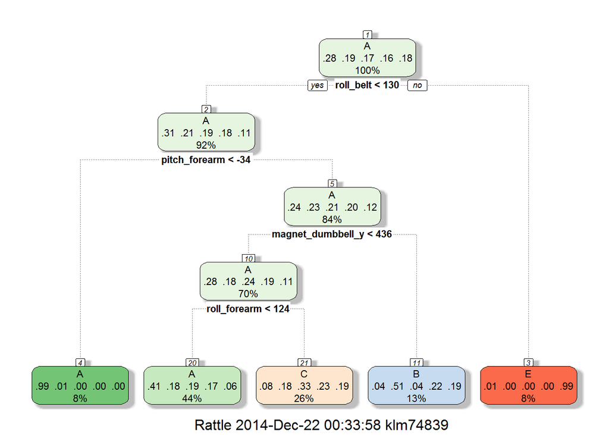

```r
library("rpart")
# Set a seed for reproducability purposes
set.seed(12345)
# Fit a random forest predictor relating the factor variable classe to the remaining variables
modFit1 <- train(classe ~ ., method="rpart", data=trainingData)
library("rattle")
fancyRpartPlot(modFit1$finalModel)
```

```r
#varImp(modFit1)
prediction1 <- predict(modFit1, newdata=validationData)
confusionMatrix(prediction1, validationData$classe)
```

```
## Confusion Matrix and Statistics
##
##           Reference
## Prediction    A    B    C    D    E
##          A 1011  331  295  288  111
##          B   20  237   30  121   98
##          C   82  191  359  234  186
##          D    0    0    0    0    0
##          E    3    0    0    0  326
##
## Overall Statistics
##
##                Accuracy : 0.493
##                  95% CI : (0.477, 0.509)
##     No Information Rate : 0.284
##     P-Value [Acc > NIR] : <2e-16
##
##                   Kappa : 0.337
##  Mcnemar's Test P-Value : NA
##
## Statistics by Class:
##
##                      Class: A Class: B Class: C Class: D Class: E
## Sensitivity             0.906   0.3123   0.5249    0.000   0.4521
## Specificity             0.635   0.9150   0.7860    1.000   0.9991
## Pos Pred Value          0.497   0.4684   0.3413      NaN   0.9909
## Neg Pred Value          0.944   0.8472   0.8868    0.836   0.8901
## Prevalence              0.284   0.1935   0.1744    0.164   0.1838
## Detection Rate          0.258   0.0604   0.0915    0.000   0.0831
## Detection Prevalence    0.519   0.1290   0.2682    0.000   0.0839
## Balanced Accuracy       0.770   0.6136   0.6554    0.500   0.7256
```

### MODELING WITH DECISION TREES - 2 -

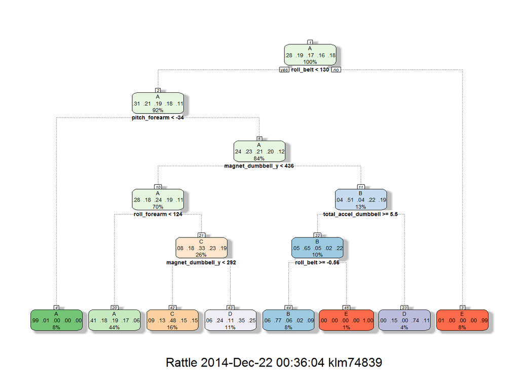

```r
# Set a seed for reproducability purposes
set.seed(23456)
modFit2 <- train(classe ~ ., method="rpart2", maxdepth = 6, data=trainingData)
library("rattle")
fancyRpartPlot(modFit2$finalModel)
```

```r
#varImp(modFit2)
prediction2 <- predict(modFit2, newdata=validationData)
confusionMatrix(prediction2, validationData$classe)
```

```
## Confusion Matrix and Statistics
##
##           Reference
## Prediction    A    B    C    D    E
##          A 1011  331  295  288  111
##          B   20  214   30   11   23
##          C   57   78  301   90   90
##          D   25  136   58  254  109
##          E    3    0    0    0  388
##
## Overall Statistics
##
##                Accuracy : 0.553
##                  95% CI : (0.537, 0.568)
##     No Information Rate : 0.284
##     P-Value [Acc > NIR] : <2e-16
##
##                   Kappa : 0.417
##  Mcnemar's Test P-Value : <2e-16
##
## Statistics by Class:
##
##                      Class: A Class: B Class: C Class: D Class: E
## Sensitivity             0.906   0.2819   0.4401   0.3950   0.5381
## Specificity             0.635   0.9735   0.9027   0.9000   0.9991
## Pos Pred Value          0.497   0.7181   0.4886   0.4364   0.9923
## Neg Pred Value          0.944   0.8497   0.8842   0.8836   0.9057
## Prevalence              0.284   0.1935   0.1744   0.1639   0.1838
## Detection Rate          0.258   0.0546   0.0767   0.0647   0.0989
## Detection Prevalence    0.519   0.0760   0.1570   0.1484   0.0997
## Balanced Accuracy       0.770   0.6277   0.6714   0.6475   0.7686
```

### Predictions for the testing data set

For this project also a random forest was run, but the processing time was too long to get the results in time to include in this document. Therefore we finally produce prediction results for the testing data using our second and improved model. You will find the results of the prediction below.

```r
testingPrediction <- predict(modFit2, newdata=testingData)
print(testingPrediction)
```

```
##  [1] C A D A A C D A A A C D C A D A A A A D
## Levels: A B C D E
```